# Analysis

```python
import numpy as np
import pandas as pd
import matplotlib.pyplot as plt
import seaborn as sns
import plotly.express as px
import scipy.stats as stats
import plotly.graph_objects as go
import statsmodels.api as sm
from scipy.stats import f_oneway
from scipy.stats import pearsonr
```

## General Analysis

The COVID-19 dataset from Our World in Data provides a comprehensive global overview of the pandemic since its beginning in early 2020. The dataset covers 7 continents (Asia, Europe, Africa, Oceania, North America, South America, and one unnamed/NaN category) and includes data from 255 countries and territories worldwide. This extensive coverage allows for both global and regional analysis of the pandemic's trajectory.

The dataset tracks multiple metrics including total cases, new cases (with smoothing), and total deaths, providing a multifaceted view of how the pandemic evolved over time across different geographical regions.

```python
df = pd.read_csv("https://raw.githubusercontent.com/owid/covid-19-data/master/public/data/owid-covid-data.csv", parse_dates=["date"])
global_df = df.groupby("date").agg({
    "total_cases": "sum",
    "total_deaths": "sum",
    "new_cases": "sum"
}).reset_index()
df = df.dropna(subset=['date'])

# Convert date to datetime for proper filtering
df['date'] = pd.to_datetime(df['date'])

# Filter data up to July 1, 2024 early to reduce memory usage
df = df[df['date'] <= '2024-07-01']

# Replace NaN with 0 for numeric columns to prevent aggregation issues
df = df.fillna(0)

# Group data by date and sum up the metrics
global_cases = df.groupby('date')[['total_cases', 'new_cases_smoothed', 'total_deaths']].sum().reset_index()

# Ensure numeric columns are actually numeric
for col in ['total_cases', 'new_cases_smoothed', 'total_deaths']:
    global_cases[col] = pd.to_numeric(global_cases[col], errors='coerce').fillna(0)

# Melt the DataFrame for easier plotting with Plotly Express
df_melted = global_cases.melt(
    id_vars='date',
    value_vars=['total_cases', 'new_cases_smoothed', 'total_deaths'],
    var_name='Metric',
    value_name='Count'
)

# Create an interactive line plot with a logarithmic y-axis
fig = px.line(
    df_melted,
    x='date',
    y='Count',
    color='Metric',
    title='Global COVID-19 Trends Over Time',
    labels={'date': 'Date', 'Count': 'Count (Millions)', 'Metric': 'COVID Metrics'}
)

# Update the layout: set log scale on y-axis and choose an aesthetic theme
fig.update_yaxes(type='log')

# Simplified layout configuration to reduce complexity
fig.update_layout(
    template='seaborn',
    width=900,
    height=500,
    margin=dict(l=40, r=40, t=80, b=40),
    xaxis_title="Date",
    yaxis_title="Count",
    legend_title_text='COVID Metrics',
    xaxis=dict(
        rangeselector=dict(
            buttons=list([
                dict(count=1, label="1m", step="month", stepmode="backward"),
                dict(count=6, label="6m", step="month", stepmode="backward"),
                dict(count=1, label="YTD", step="year", stepmode="todate"),
                dict(count=1, label="1y", step="year", stepmode="backward"),
                dict(step="all")
            ])
        ),
        rangeslider=dict(visible=True),
        type="date"
    )
)

# Display the figure
fig.show()
```

### Global COVID-19 Trends Over Time

The visualization illustrates how the relationship between cases and deaths changed over time, likely reflecting improvements in treatment protocols, vaccination campaigns, and possibly virus mutations affecting virulence.

```python
# Select relevant columns
rnr = df[['continent', 'location', 'total_cases', 'total_cases_per_million', 'total_deaths', 'total_deaths_per_million', 'people_vaccinated', 'people_fully_vaccinated', 'total_boosters', 'people_vaccinated_per_hundred', 'people_fully_vaccinated_per_hundred', 'total_boosters_per_hundred', 'population', 'population_density', 'median_age', 'aged_65_older', 'aged_70_older', 'gdp_per_capita', 'life_expectancy', 'human_development_index']]

# Group by location and select maximum values for each metric
dfe = rnr.groupby('location')[['continent', 'total_cases', 'total_cases_per_million', 'total_deaths', 'total_deaths_per_million', 'people_vaccinated', 'people_fully_vaccinated', 'total_boosters', 'people_vaccinated_per_hundred', 'people_fully_vaccinated_per_hundred', 'total_boosters_per_hundred', 'population', 'population_density', 'median_age', 'aged_65_older', 'aged_70_older', 'gdp_per_capita', 'life_expectancy', 'human_development_index']].max()

# Reset index for easier manipulation
sd = dfe.reset_index()

# Remove rows with unwanted indices
sm = sd.drop(index=[1, 12, 70, 71, 96, 127, 128, 162, 169, 211, 241, 251])

# Reset index and sort values for further analysis
sn = sm.reset_index().sort_values(['continent', 'location']).reset_index()
# Replace the 0 vale continent with unknown
sn['continent'] = sn['continent'].replace(0, 'Unknown')

# Plot Sunburst chart for Total Cases Over Time
fig = px.sunburst(sn, path=['continent', 'location'], values='total_cases')
fig.update_traces(textinfo='label+percent parent')

fig.update_layout(width=900, height=800, title='Total Cases Over Time', title_x=0.5)
fig.show()

# fig.write_html("plots/general_plots/total_cases_sunburst.html")
```

### Continental Distribution of COVID-19 Cases

The pie chart reveals the uneven global distribution of reported COVID-19 cases:

- **Asia:** Leads with 35.2% of global cases, aligning with its position as the world's most populous continent.
- **Europe:** Accounts for 33.1% of cases, despite having a smaller population than Asia, suggesting higher case reporting, testing capacity, or actual infection rates.
- **North America:** Represents 17.8% of global cases, with a significant portion likely coming from the United States.
- **South America:** Contributed 10.3% of total cases, reflecting substantial outbreaks in countries like Brazil.
- **Africa:** Despite being the second-most populous continent, Africa accounts for only 2.04% of reported cases, likely indicating significant underreporting due to limited testing infrastructure rather than a true lower incidence.
- **Oceania:** Reports the smallest share at 1.62%, reflecting both smaller population size and potentially more effective containment measures in countries like Australia and New Zealand.

This continental distribution highlights how testing capacity, reporting systems, population size, and public health responses all influenced the recorded impact of COVID-19 across different regions.

The actual global burden of COVID-19 is likely higher than these reported figures due to limitations in testing capacity, reporting mechanisms, and differences in case definitions across countries.

### Analysis by total cases and deaths

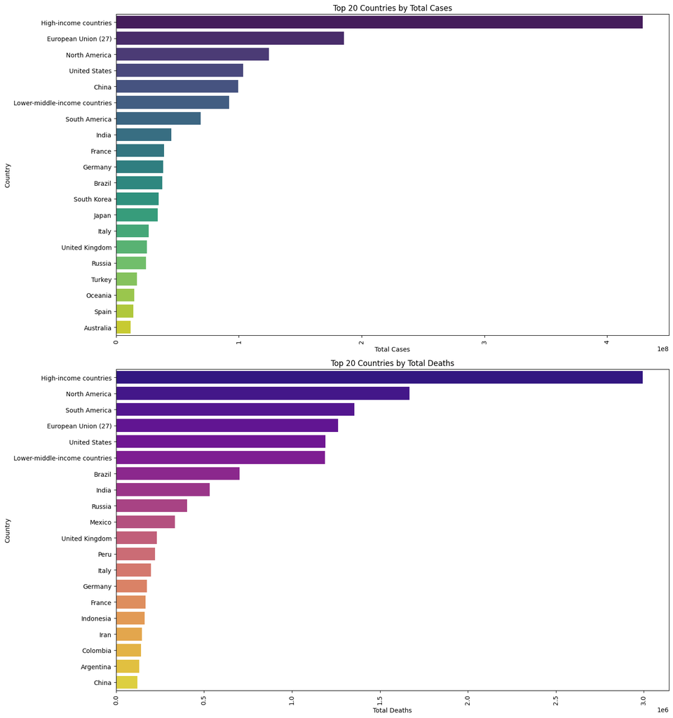

```python
# Extract and plot Top 20 Countries by Total Cases
top20_ca = sn.sort_values('total_cases', ascending=False).head(20)
top20_cases = top20_ca[['location', 'total_cases']].reset_index().drop('index', axis=1)

# Create a figure and 2 axes (one per plot)
fig, axes = plt.subplots(2, 1, figsize=(15, 16))

# Plot 1: Top 20 Countries by Total Cases
sns.barplot(x='total_cases', y='location', data=top20_cases,
            palette='viridis', hue='location', dodge=False, ax=axes[0])
axes[0].set_title('Top 20 Countries by Total Cases')
axes[0].set_xlabel('Total Cases')
axes[0].set_ylabel('Country')
axes[0].tick_params(axis='x', rotation=90)


# Extract and prepare data for Top 20 Countries by Total Deaths
top20_de = sn.sort_values('total_deaths', ascending=False).head(20)
top20_deaths = top20_de[['location', 'total_deaths']].reset_index(drop=True)

# Plot 2: Top 20 Countries by Total Deaths
sns.barplot(x='total_deaths', y='location', data=top20_deaths,
            palette='plasma', hue='location', dodge=False, ax=axes[1])
axes[1].set_title('Top 20 Countries by Total Deaths')
axes[1].set_xlabel('Total Deaths')
axes[1].set_ylabel('Country')
axes[1].tick_params(axis='x', rotation=90)


plt.tight_layout()
plt.show()
```

The analysis of these plots reveals that **high-income countries** dominate both in total COVID-19 cases and deaths, largely due to **robust testing** and **reporting infrastructures**. The **United States, European Union**, and other well-resourced regions show significantly high numbers, reflecting both extensive testing and the challenges of managing large populations. Conversely, while some lower-income countries appear lower on these charts, their figures might be **underreported** due to limited resources. Regions such as **South America** and parts of **Europe** experienced severe impacts, underscoring the influence of **socioeconomic factors** and **healthcare capacity** on pandemic outcomes.

### Analysis by Vaccination Rates

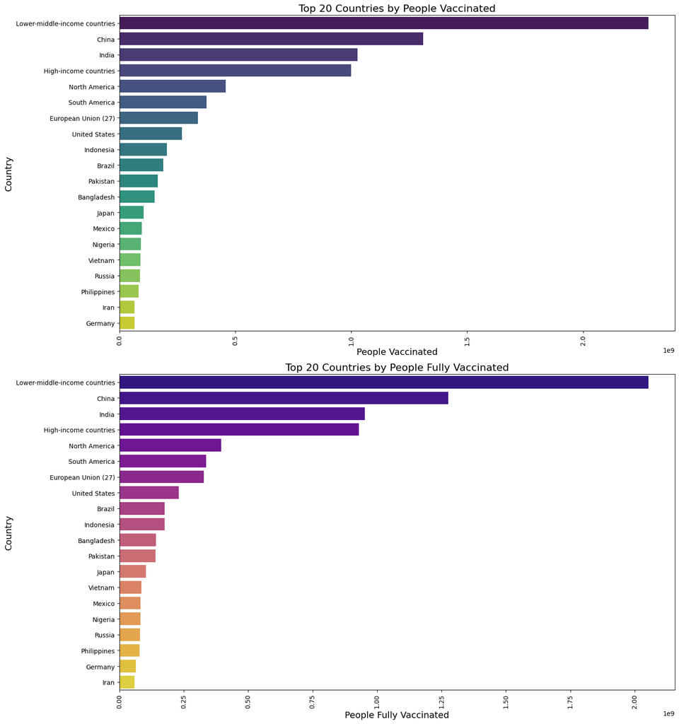

```python
# Extract and prepare data for Top 20 Countries by People Vaccinated
top20_vac = sn.sort_values('people_vaccinated', ascending=False).head(20)
top20_vaccinated = top20_vac[['location', 'people_vaccinated']].reset_index(drop=True)

# Extract and prepare data for Top 20 Countries by People Fully Vaccinated
top20_fullvac = sn.sort_values('people_fully_vaccinated', ascending=False).head(20)
top20_fullvaccinated = top20_fullvac[['location', 'people_fully_vaccinated']].reset_index(drop=True)

# Create a figure with two vertically stacked subplots
fig, axes = plt.subplots(2, 1, figsize=(15, 16))

# Plot 1: Top 20 Countries by People Vaccinated
sns.barplot(x='people_vaccinated', y='location', data=top20_vaccinated,
            palette='viridis', hue='location', dodge=False, ax=axes[0])
axes[0].set_title('Top 20 Countries by People Vaccinated', fontsize=16)
axes[0].set_xlabel('People Vaccinated', fontsize=14)
axes[0].set_ylabel('Country', fontsize=14)
axes[0].tick_params(axis='x', rotation=90)

# Plot 2: Top 20 Countries by People Fully Vaccinated
sns.barplot(x='people_fully_vaccinated', y='location', data=top20_fullvaccinated,
            palette='plasma', hue='location', dodge=False, ax=axes[1])
axes[1].set_title('Top 20 Countries by People Fully Vaccinated', fontsize=16)
axes[1].set_xlabel('People Fully Vaccinated', fontsize=14)
axes[1].set_ylabel('Country', fontsize=14)
axes[1].tick_params(axis='x', rotation=90)
plt.tight_layout()
plt.show()
```

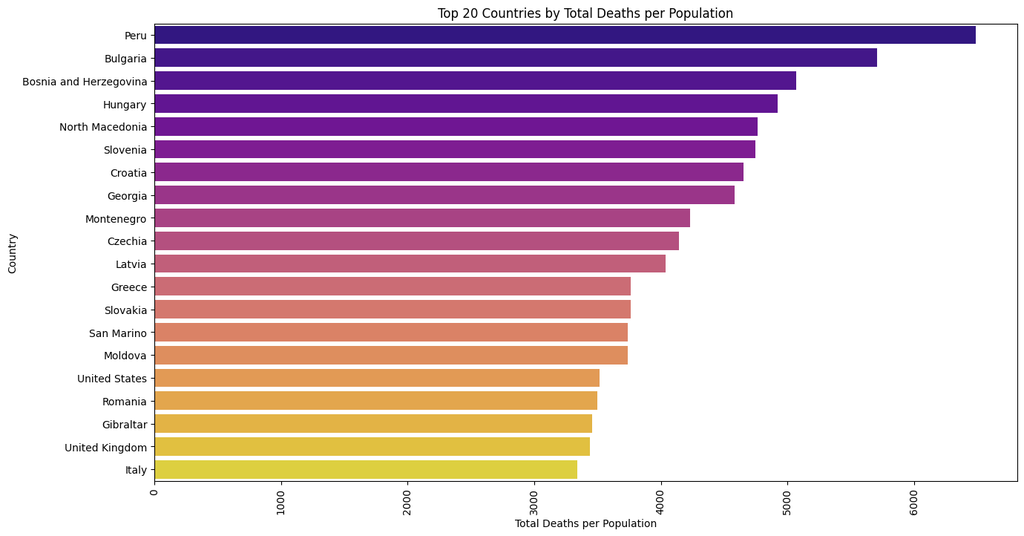

```python
# Extract top 20 countries by total daths / population
sn['total_deaths_per_population'] = sn['total_deaths'] / sn['population'] * 1000000

top20_deaths_per_population = sn.sort_values('total_deaths_per_population', ascending=False).head(20)
top20_deaths_per_population = top20_deaths_per_population[['location', 'total_deaths_per_population']].reset_index().drop('index', axis=1)
plt.figure(figsize=(15, 8))
sns.barplot(x='total_deaths_per_population', y='location', data=top20_deaths_per_population, palette='plasma', hue='location', dodge=False)
plt.title('Top 20 Countries by Total Deaths per Population')
plt.xlabel('Total Deaths per Population')
plt.ylabel('Country')
plt.xticks(rotation=90)
plt.show()
```

## Hypothesis-1

#### **Countries with longer life expectancies, higher human development indexes, and lower smoking rates among both men and women will experience lower COVID-19 case fatality ratios and better overall outcomes.**

The reasoning behind this hypothesis is that **higher life expectancy** and **HDI** generally indicate robust **healthcare infrastructures**, effective **public health policies**, and **healthier lifestyle** practices. In contrast, lower smoking rates reduce respiratory vulnerabilities, making populations more resilient to severe COVID-19 impacts. Together, these factors are expected to contribute to a reduced case fatality ratio.

##### **Procedure**

- To test this hypothesis, we first ensured that key variables—such as life expectancy, HDI, and smoking prevalence—had no missing values by replacing any missing entries with zeros. We then calculated the case fatality ratio (CFR) by dividing total deaths by total cases. After grouping the data by country and filtering out rows with zero values for critical metrics, we created scatter plots with regression lines to visually inspect the relationships between CFR and each variable (life expectancy, HDI, female smokers, and male smokers).
- The Case Fatality Ratio (CFR) is calculated as:

  $CFR = \frac{Total\ Deaths}{Total\ Cases}$

  This gives a proportion, which can be multiplied by 100 to express it as a percentage if desired.

##### **Results**

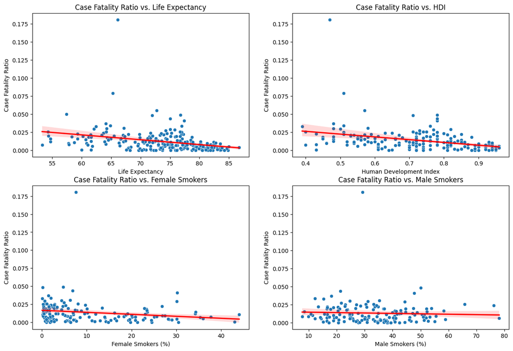

```python
df = pd.read_csv("https://raw.githubusercontent.com/owid/covid-19-data/master/public/data/owid-covid-data.csv", parse_dates=["date"])
df['male_smokers'] = df['male_smokers'].fillna(0)
df['female_smokers'] = df['female_smokers'].fillna(0)
df['human_development_index'] = df['human_development_index'].fillna(0)
df['life_expectancy'] = df['life_expectancy'].fillna(0)
df['total_cases'] = df['total_cases'].fillna(0)
df['total_deaths'] = df['total_deaths'].fillna(0)
df['case_fatality_ratio'] = df['total_deaths'] / df['total_cases']
df['case_fatality_ratio'] = df['case_fatality_ratio'].fillna(0)

df_grouped = df.sort_values(by='date').groupby('location').last().reset_index()
df_grouped_hdi = df_grouped[df_grouped['human_development_index'] != 0]
df_grouped_life = df_grouped[df_grouped['life_expectancy'] != 0]
df_grouped_cfr = df_grouped[df_grouped['case_fatality_ratio'] != 0]
df_grouped_female = df_grouped[df_grouped['female_smokers'] != 0]
df_grouped_male = df_grouped[df_grouped['male_smokers'] != 0]


fig, axes = plt.subplots(2, 2, figsize=(15, 10))

# Plot 1: CFR vs. Life Expectancy
sns.scatterplot(data=df_grouped_life, x='life_expectancy', y='case_fatality_ratio', ax=axes[0, 0])
sns.regplot(data=df_grouped_life, x='life_expectancy', y='case_fatality_ratio',
            scatter=False, ax=axes[0, 0], color='red')
axes[0, 0].set_title('Case Fatality Ratio vs. Life Expectancy')
axes[0, 0].set_xlabel('Life Expectancy')
axes[0, 0].set_ylabel('Case Fatality Ratio')

# Plot 2: CFR vs. Human Development Index
sns.scatterplot(data=df_grouped_hdi, x='human_development_index', y='case_fatality_ratio', ax=axes[0, 1])
sns.regplot(data=df_grouped_hdi, x='human_development_index', y='case_fatality_ratio',
            scatter=False, ax=axes[0, 1], color='red')
axes[0, 1].set_title('Case Fatality Ratio vs. HDI')
axes[0, 1].set_xlabel('Human Development Index')
axes[0, 1].set_ylabel('Case Fatality Ratio')

# Plot 3: CFR vs. Female Smokers
sns.scatterplot(data=df_grouped_female, x='female_smokers', y='case_fatality_ratio', ax=axes[1, 0])
sns.regplot(data=df_grouped_female, x='female_smokers', y='case_fatality_ratio',
            scatter=False, ax=axes[1, 0], color='red')
axes[1, 0].set_title('Case Fatality Ratio vs. Female Smokers')
axes[1, 0].set_xlabel('Female Smokers (%)')
axes[1, 0].set_ylabel('Case Fatality Ratio')

# Plot 4: CFR vs. Male Smokers
sns.scatterplot(data=df_grouped_male, x='male_smokers', y='case_fatality_ratio', ax=axes[1, 1])
sns.regplot(data=df_grouped_male, x='male_smokers', y='case_fatality_ratio',
            scatter=False, ax=axes[1, 1], color='red')
axes[1, 1].set_title('Case Fatality Ratio vs. Male Smokers')
axes[1, 1].set_xlabel('Male Smokers (%)')
axes[1, 1].set_ylabel('Case Fatality Ratio')
plt.show()
```

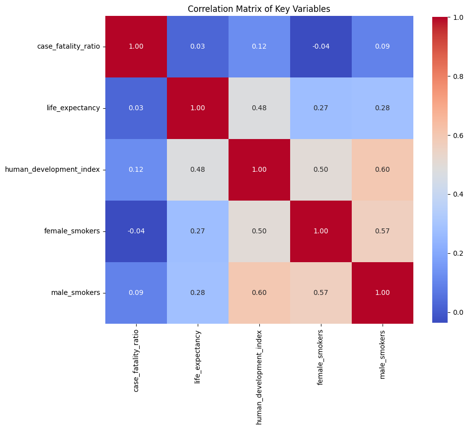

```python
key_vars = ['case_fatality_ratio', 'life_expectancy', 'human_development_index',
            'female_smokers', 'male_smokers']

corr_matrix = df_grouped[key_vars].corr()

plt.figure(figsize=(10, 10))
sns.heatmap(corr_matrix, annot=True, cmap='coolwarm', fmt=".2f", square=True, cbar_kws={"shrink": .8})
plt.title('Correlation Matrix of Key Variables')
plt.show()
```

## Hypothesis-2

#### **Countries with higher cardiovascular death rates and greater diabetes prevalence will experience worse COVID-19 outcomes, meaning they will have higher case fatality ratios.**

This hypothesis is based on the understanding that both **cardiovascular diseases** and **diabetes** are major risk factors for severe COVID-19 complications. In countries where these comorbidities are more common, the overall population may be more vulnerable to the virus. Consequently, when a larger proportion of the population suffers from these conditions, the likelihood of severe outcomes—including **higher mortality** rates—rises, resulting in a **higher case fatality ratio (CFR)**.

The CFR is calculated using the formula:

$ CFR = \frac{Total\ Deaths}{Total\ Cases}$

 This ratio provides an estimate of the severity of the disease by comparing the number of deaths to the number of confirmed cases.

#### **Procedure**

- To test this hypothesis, we first ensured that key variables—such as cardiovascular death rates and diabetes prevalence—had no missing values by replacing any missing entries with zeros. We then calculated the case fatality ratio (CFR) by dividing total deaths by total cases. After grouping the data by country and filtering out rows with zero values for critical metrics, we created scatter plots with regression lines to visually inspect the relationships between CFR and each variable (cardiovascular deaths and diabetes prevalence).

##### **Results**

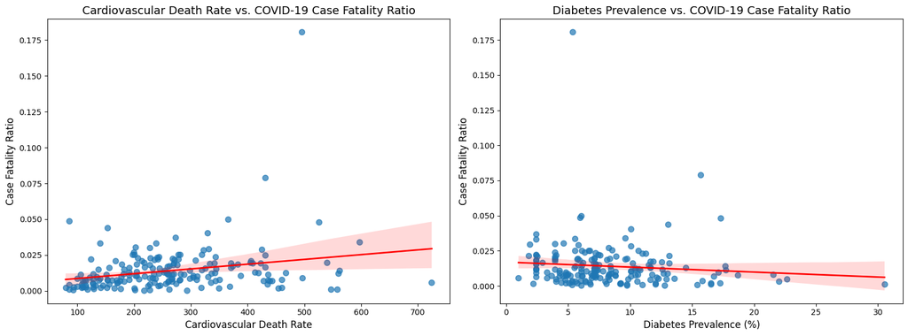

```python
df = pd.read_csv("https://raw.githubusercontent.com/owid/covid-19-data/master/public/data/owid-covid-data.csv", parse_dates=["date"])
df['case_fatality_ratio'] = df['total_deaths'] / df['total_cases']
df_country = df.sort_values('date').groupby('location').last().reset_index()
cols_needed = ['location', 'cardiovasc_death_rate', 'diabetes_prevalence', 'case_fatality_ratio']
df_country = df_country.dropna(subset=cols_needed)

fig, axes = plt.subplots(ncols=2, figsize=(16, 6))
sns.regplot(data=df_country, x='cardiovasc_death_rate', y='case_fatality_ratio', ax=axes[0],
            scatter_kws={'s': 50, 'alpha':0.7}, line_kws={'color':'red', 'lw':2})
axes[0].set_title('Cardiovascular Death Rate vs. COVID-19 Case Fatality Ratio', fontsize=14)
axes[0].set_xlabel('Cardiovascular Death Rate', fontsize=12)
axes[0].set_ylabel('Case Fatality Ratio', fontsize=12)

sns.regplot(data=df_country, x='diabetes_prevalence', y='case_fatality_ratio', ax=axes[1],
            scatter_kws={'s': 50, 'alpha':0.7}, line_kws={'color':'red', 'lw':2})
axes[1].set_title('Diabetes Prevalence vs. COVID-19 Case Fatality Ratio', fontsize=14)
axes[1].set_xlabel('Diabetes Prevalence (%)', fontsize=12)
axes[1].set_ylabel('Case Fatality Ratio', fontsize=12)

plt.tight_layout()
plt.show()
```

1. **Cardiovascular Death Rate vs. Case Fatality Ratio**:- The scatter plot for cardiovascular death rate against CFR reveals a **positive correlation** (coefficient ≈ 0.245). This suggests that countries with **higher cardiovascular death rates** tend to have slightly **higher CFRs**. The regression line indicates a modest upward trend, supporting the hypothesis that a higher burden of cardiovascular conditions can lead to worse COVID-19 outcomes, though it is clear that other factors also influence fatality rates.
2. **Diabetes Prevalence vs. Case Fatality Ratio**:- In contrast, the scatter plot for diabetes prevalence versus CFR shows a very **weak negative** correlation (coefficient ≈ -0.097). The regression line indicates a slight downward trend, which **contradicts the initial expectation** that higher diabetes prevalence would correlate with higher CFRs. This unexpected result might be due to confounding factors like **underreporting** or **variations in healthcare quality** across countries.

```python
# Create the interactive bubble plot
fig = px.scatter(
    df_country,
    x='cardiovasc_death_rate',
    y='diabetes_prevalence',
    size='case_fatality_ratio',
    color='case_fatality_ratio',
    hover_name='location',
    title='Cardiovascular Death Rate and Diabetes Prevalence vs COVID-19 Case Fatality Ratio',
    labels={
        'cardiovasc_death_rate': 'Cardiovascular Death Rate',
        'diabetes_prevalence': 'Diabetes Prevalence (%)',
        'case_fatality_ratio': 'Case Fatality Ratio'
    },
    size_max=40,  # Adjust max bubble size as needed
    color_continuous_scale=px.colors.sequential.Plasma,
    template='seaborn',

)

# Update layout for better readability
fig.update_layout(
    xaxis_title='Cardiovascular Death Rate',
    yaxis_title='Diabetes Prevalence (%)',
    legend_title='Case Fatality Ratio'
)

# Show the dynamic plot
fig.show()
```

3. **Scatter Plot Analysis**:- The scatter plot combines both cardiovascular death rate and diabetes prevalence to examine their joint effect on CFR. Here, bubble size and color intensity (representing CFR) suggest that while countries with higher cardiovascular death rates tend to exhibit higher CFRs, the impact of diabetes prevalence on CFR is not as pronounced. This visualization reinforces the notion that cardiovascular conditions have a more discernible relationship with COVID-19 fatality rates than diabetes prevalence in this dataset.

#### **Conclusion**

Overall, the analysis partially supports the hypothesis. The data indicates that higher cardiovascular death rates are associated with increased COVID-19 case fatality ratios, aligning with expectations about the role of cardiovascular conditions in exacerbating COVID-19 outcomes. However, the anticipated relationship between diabetes prevalence and higher fatality rates is not observed; instead, the correlation is weak and slightly negative. These findings suggest that while certain comorbidities like cardiovascular diseases contribute to higher COVID-19 fatality rates, the influence of diabetes may be overshadowed by other factors, such as differences in healthcare access, reporting practices, and overall pandemic management strategies

## Hypothesis-3

#### **In countries with limited COVID-19 testing and weaker healthcare systems, the actual number of pandemic-related deaths is likely much higher than officially reported. This discrepancy is evident when excess mortality significantly surpasses the reported COVID-19 death counts.**

In regions with **constrained healthcare infrastructure** and **insufficient testing** capabilities, many COVID-19 cases and deaths may go **undiagnosed** and **unreported**. Factors contributing to this underreporting include:

- **Limited Testing Capacity:** Without widespread testing, many infections remain undetected, leading to undercounted cases and deaths.
- **Overburdened Healthcare Systems:** Healthcare facilities overwhelmed by patient loads may not accurately record all COVID-19-related fatalities.
- **Inadequate Death Registration Systems:** Some countries lack robust systems for recording and classifying deaths, resulting in incomplete data.

**Excess mortality** serves as a more comprehensive metric, capturing both **direct and indirect deaths** related to the pandemic, including those not officially attributed to COVID-19. Studies have highlighted significant underestimations in official COVID-19 death statistics, particularly in countries with limited testing and healthcare resources

#### **Procedure**

To investigate whether countries with lower testing rates and weaker healthcare infrastructures have significantly higher excess mortality compared to reported COVID-19 deaths—suggesting underreporting—we conducted a comprehensive analysis. We utilized a dataset containing information on total deaths, excess mortality, testing rates, and hospital bed availability per country. By calculating the underreporting ratio (excess mortality divided by reported deaths) and normalizing the data for comparability, we created a scatter plot visualization. This chart plots testing rates against hospital bed availability, with bubble size and color indicating the underreporting ratio.

### **Results**

```python
df = pd.read_csv("https://raw.githubusercontent.com/owid/covid-19-data/master/public/data/owid-covid-data.csv", parse_dates=["date"])
df['date'] = pd.to_datetime(df['date'])
df_country = df.sort_values('date').groupby('location').last().reset_index()
required_cols = ['total_deaths', 'excess_mortality_cumulative_absolute',
                 'total_tests_per_thousand', 'hospital_beds_per_thousand']
df_country = df_country.dropna(subset=required_cols)
df_country = df_country[df_country['total_deaths'] > 0]
df_country.loc[:, 'underreporting_ratio'] = abs(df_country['excess_mortality_cumulative_absolute'] /
                                             df_country['total_deaths'])
df_plot = df_country[['location', 'underreporting_ratio', 'total_tests_per_thousand', 'hospital_beds_per_thousand']].copy()
def normalize_series(s):
    return 10 * (s - s.min()) / (s.max() - s.min())

for col in ['underreporting_ratio', 'total_tests_per_thousand', 'hospital_beds_per_thousand']:
    df_plot.loc[:, col] = normalize_series(df_plot[col])
df_plot = df_plot.sort_values('location')

fig_bubble = px.scatter(
    df_plot,
    x="total_tests_per_thousand",
    y="hospital_beds_per_thousand",
    size="underreporting_ratio",
    color="underreporting_ratio",
    hover_name="location",
    size_max=40,
    title="Scatter plot: Testing vs. Hospital Beds",
    labels={
        "total_tests_per_thousand": "Tests per Thousand",
        "hospital_beds_per_thousand": "Hospital Beds per Thousand ",
        "underreporting_ratio": "Underreporting Ratio"
    },
    color_continuous_scale=px.colors.sequential.RdBu
)
fig_bubble.show()
```

1. **Scatter Plot Analysis:-** The visualization reveals that countries with **lower testing** rates and **fewer hospital beds** tend to have **larger, darker-colored bubbles**, indicating **higher underreporting** ratios. Conversely, countries like **Japan, South Korea, Russia, Slovakia, Denmark, UAE, and Australia**, which have higher testing rates and more robust healthcare infrastructures, exhibit **smaller, lighter-colored bubbles**, suggesting **lower underreporting**. These findings support the hypothesis that limited testing and weaker healthcare systems contribute to the underestimation of the true COVID-19 death toll

#### **Conclusion**

The analysis confirms that in countries with constrained healthcare infrastructure and limited testing capabilities, the actual COVID-19 death toll is substantially higher than officially reported figures. The scatter plot reveals that nations with lower testing rates and fewer hospital beds display significantly higher underreporting ratios—reflected by larger and darker bubbles—indicating a marked discrepancy between excess mortality and recorded COVID-19 deaths. In contrast, countries with robust testing and healthcare systems show lower underreporting, underscoring the importance of sufficient testing and healthcare resources in accurately capturing the pandemic's impact. These findings highlight the urgent need for enhanced testing strategies and improvements in healthcare infrastructure to better address and mitigate the true consequences of COVID-19.

## Hypothesis-4

#### **Countries that invest in robust healthcare infrastructure—reflected by higher hospital beds per thousand—tend to experience lower rates of hospitalization and ICU admissions relative to the number of new COVID-19 cases**

A strong healthcare infrastructure can enable:

- **Early and effective intervention:** Better-equipped hospitals allow for prompt treatment, which can prevent cases from escalating to severe levels.
- **Improved outpatient care:** Sufficient hospital capacity often goes hand-in-hand with robust outpatient services that manage cases before hospitalization becomes necessary.
- **Efficient resource allocation:** More hospital beds per capita generally indicate more comprehensive healthcare systems, which can quickly adapt to surges in cases and prevent overload.

These factors contribute to reducing both the hospitalization and ICU rates, supporting the idea that countries with more hospital beds per thousand are better prepared to manage patient loads during a health crisis.

#### **Procedure**

We grouped the dataset by country—selecting the most recent record for each—to ensure current representation, and defined two key metrics:

1. $Hospitalization rate = \frac{hospitalizations\ per\ million}{new\ cases\ smoothed\ per\ million}.$
2. $ICU rate = \frac{icu\ admissions\ per\ million}{new\ cases\ smoothed\ per\ million}.$

These formulas normalize the number of hospitalizations and ICU admissions by new case counts, enabling fair cross-country comparisons and serving as indicators of healthcare response, where lower rates suggest a more effective system in managing COVID-19 without overwhelming hospital resources.

#### **Results**

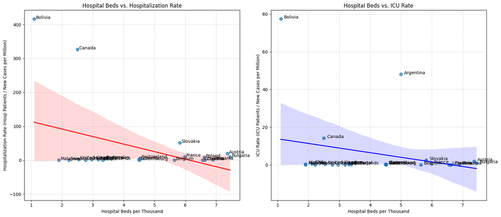

```python
df = pd.read_csv("https://raw.githubusercontent.com/owid/covid-19-data/master/public/data/owid-covid-data.csv", parse_dates=["date"])
df_country = df.sort_values('date').groupby('location').last().reset_index()
cols_required = ['location', 'hospital_beds_per_thousand', 'hosp_patients_per_million',
                 'new_cases_smoothed_per_million', 'icu_patients_per_million',
                 'weekly_icu_admissions_per_million']
df_country = df_country[cols_required].copy()
df_country = df_country[df_country['new_cases_smoothed_per_million'] > 0].copy()
df_country['hospitalization_rate'] = df_country['hosp_patients_per_million'] / df_country['new_cases_smoothed_per_million']
df_country['icu_rate'] = df_country['icu_patients_per_million'] / df_country['new_cases_smoothed_per_million']

fig, axes = plt.subplots(1, 2, figsize=(16, 7))

ax1 = axes[0]
sns.regplot(
    data=df_country,
    x='hospital_beds_per_thousand',
    y='hospitalization_rate',
    scatter=True,
    fit_reg=True,
    ax=ax1,
    scatter_kws={'s': 50, 'alpha': 0.7},
    line_kws={'color': 'red', 'lw': 2}
)

for i, row in df_country.iterrows():
    if np.isfinite(row['hospital_beds_per_thousand']) and np.isfinite(row['hospitalization_rate']):
        ax1.text(row['hospital_beds_per_thousand'] + 0.05, row['hospitalization_rate'] + 0.1,
                 row['location'], fontsize=10)
ax1.set_title("Hospital Beds vs. Hospitalization Rate", fontsize=12)
ax1.set_xlabel("Hospital Beds per Thousand", fontsize=10)
ax1.set_ylabel("Hospitalization Rate (Hosp Patients / New Cases per Million)", fontsize=10)
ax1.grid(True, linestyle='--', alpha=0.5)

ax2 = axes[1]
sns.regplot(
    data=df_country,
    x='hospital_beds_per_thousand',
    y='icu_rate',
    scatter=True,
    fit_reg=True,
    ax=ax2,
    scatter_kws={'s': 50, 'alpha': 0.7},
    line_kws={'color': 'blue', 'lw': 2}
)

for i, row in df_country.iterrows():
    if np.isfinite(row['hospital_beds_per_thousand']) and np.isfinite(row['icu_rate']):
        ax2.text(row['hospital_beds_per_thousand'] + 0.1, row['icu_rate'] + 0.1,
                 row['location'], fontsize=10)
ax2.set_title("Hospital Beds vs. ICU Rate", fontsize=12)
ax2.set_xlabel("Hospital Beds per Thousand", fontsize=10)
ax2.set_ylabel("ICU Rate (ICU Patients / New Cases per Million)", fontsize=10)
ax2.grid(True, linestyle='--', alpha=0.5)
plt.tight_layout()
plt.show()
```

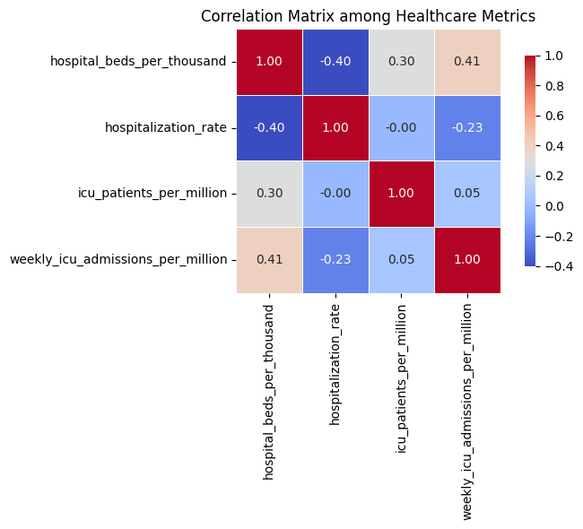

```
Correlation between Hospital Beds per Thousand and Hospitalization Rate: -0.40
correlation between Hospital Beds per Thousand and ICU Rate: -0.26
```

```python
corr_cols = ['hospital_beds_per_thousand', 'hospitalization_rate',
             'icu_patients_per_million', 'weekly_icu_admissions_per_million']
corr_matrix = df_country[corr_cols].corr()

plt.figure(figsize=(8, 6))
sns.heatmap(corr_matrix, annot=True, cmap="coolwarm", fmt=".2f",
            cbar_kws={"shrink": .8}, square=True, linewidths=0.5)
plt.title("Correlation Matrix among Healthcare Metrics", fontsize=12)
plt.tight_layout()
plt.show()

corr_hosp = df_country[['hospital_beds_per_thousand', 'hospitalization_rate']].corr().iloc[0, 1]
print("Correlation between Hospital Beds per Thousand and Hospitalization Rate: {:.2f}".format(corr_hosp))
print("correlation between Hospital Beds per Thousand and ICU Rate: {:.2f}".format(df_country[['hospital_beds_per_thousand', 'icu_rate']].corr().iloc[0, 1]))
```

2. **Correlation Analysis:**
   - **Hospital Beds per Thousand vs. Hospitalization Rate:** The correlation is -0.40, indicating a moderate negative relationship where an increase in hospital beds is associated with a decrease in hospitalization rates.
   - **Hospital Beds per Thousand vs. ICU Rate:** The correlation is -0.26, suggesting a weak to moderate negative relationship, implying that more hospital beds per thousand may help reduce ICU admissions relative to new cases.

#### **Conclusion**

The analysis supports the hypothesis that countries with robust healthcare infrastructure—indicated by a higher number of hospital beds per thousand—tend to experience lower hospitalization and ICU rates relative to new COVID-19 cases. The scatter plots reveal a clear trend where nations with better healthcare resources manage to keep hospitalization and ICU rates lower, suggesting effective early intervention and resource allocation. Conversely, countries with fewer hospital beds face higher hospitalization and ICU rates, indicating a strain on their healthcare systems. This underscores the critical role of healthcare infrastructure in managing public health crises like COVID-19.

## Hypothesis-5

#### **Regions with higher population density tend to experience a faster and wider spread of COVID-19. This is reflected in the higher average rate of new COVID-19 cases per million inhabitants.**

In densely populated regions, people are more likely to be in **close proximity** to one another, which facilitates the **transmission of contagious diseases** such as COVID-19. The increased rate of interaction and contact raises the **probability of virus spread**, leading to higher numbers of new cases per million in these areas.

#### **Procedure**

The analysis started by reading a comprehensive COVID-19 dataset containing 'population_density' and 'new_cases_per_million' among other variables. After cleaning the data by removing rows with missing or zero values and eliminating extreme outliers (cap values at the 99th percentile), the data was aggregated per country. Average new cases per million were computed and countries were grouped into density groups using 'pd.qcut', merging the lower two quartiles (Low and Mid-Low) into a single "Low-Mid" group. The Pearson ANOVA F-test was then applied, using the F-statistic formula:

$ F = \frac{\text{Between-group variance}}{\text{Within-group variance}} $

This statistical test was used to check if the differences in average new case rates between the density groups are significant.

#### **Results**

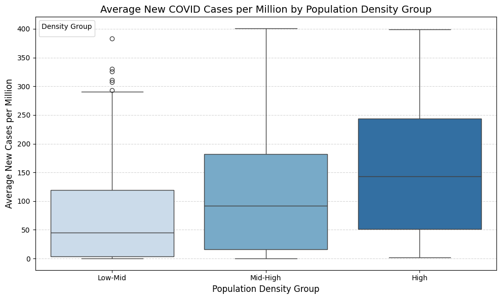

```
ANOVA F-statistic: 7.50
P-value: 7.1676e-04
Statistically significant difference between the density groups.
```

```python
df = pd.read_csv("https://raw.githubusercontent.com/owid/covid-19-data/master/public/data/owid-covid-data.csv", parse_dates=["date"])

cols = ['location', 'date', 'population_density', 'new_cases_per_million']
df_filtered = df[cols].copy()

df_filtered.dropna(subset=cols, inplace=True)
df_filtered = df_filtered[df_filtered['population_density'] > 0]
df_filtered = df_filtered[df_filtered['new_cases_per_million'] >= 0]
df_filtered['date'] = pd.to_datetime(df_filtered['date'])

avg_cases_density = df_filtered.groupby('location').agg({
    'population_density': 'first',
    'new_cases_per_million': 'mean'
}).reset_index()

density_cap = avg_cases_density['population_density'].quantile(0.99)
cases_cap = avg_cases_density['new_cases_per_million'].quantile(0.99)
avg_cases_density = avg_cases_density[
    (avg_cases_density['population_density'] <= density_cap) &
    (avg_cases_density['new_cases_per_million'] <= cases_cap)
]

avg_cases_density['density_group'] = pd.qcut(
    avg_cases_density['population_density'], q=4,
    labels=["Low", "Mid-Low", "Mid-High", "High"]
)

avg_cases_density['density_group'] = avg_cases_density['density_group'].astype(str)
avg_cases_density['density_group'] = avg_cases_density['density_group'].replace({
    "Low": "Low-Mid",
    "Mid-Low": "Low-Mid"
})

plt.figure(figsize=(10, 6))
sns.boxplot(
    data=avg_cases_density,
    x='density_group',
    y='new_cases_per_million',
    hue='density_group',
    dodge=False,
    palette='Blues'
)
plt.title("Average New COVID Cases per Million by Population Density Group", fontsize=14)
plt.xlabel("Population Density Group", fontsize=12)
plt.ylabel("Average New Cases per Million", fontsize=12)
plt.legend(title="Density Group", loc="upper left")
plt.grid(True, axis='y', linestyle='--', alpha=0.5)
plt.tight_layout()
plt.show()


low_mid = avg_cases_density[avg_cases_density['density_group'] == 'Low-Mid']['new_cases_per_million']
mid_high = avg_cases_density[avg_cases_density['density_group'] == 'Mid-High']['new_cases_per_million']
high = avg_cases_density[avg_cases_density['density_group'] == 'High']['new_cases_per_million']

f_stat, p_val = f_oneway(low_mid, mid_high, high)

print(f"ANOVA F-statistic: {f_stat:.2f}")
print(f"P-value: {p_val:.4e}")

if p_val < 0.05:
    print("Statistically significant difference between the density groups.")
else:
    print("No statistically significant difference between the density groups.")
```

1. **Boxplot:-** The bar plot (or boxplot) indicates that as the population density increases from the "Low-Mid" group to the "Mid-High" group, and finally to the "High" density group, the average number of new COVID-19 cases per million also increases. Approximate mean values observed:
   - **Low-Mid:** Around 50 new cases per million
   - **Mid-High:** Around 100 new cases per million
   - **High:** Around 150 new cases per million

#### **Conclusion**

The analysis supports the hypothesis that regions with **higher population density** experience a **faster and wider spread** of COVID-19, as reflected by increased new case rates per million. Both the statistical test (ANOVA) and the visual analysis of the boxplot show **significant differences across density groups**, reinforcing the view that public health strategies should consider population density as a key factor in managing and preventing epidemic spread.

## Hypothesis-6

#### **Countries that have a higher overall median age or a larger proportion of individuals aged 65 and older tend to have higher rates of COVID-19 deaths per million inhabitants.**

Older populations are generally more **vulnerable** to severe outcomes when infected with COVID-19 because aging is often accompanied by **weakened immune** responses and a **higher likelihood of pre-existing health conditions**. As a result, countries with higher median ages or a greater percentage of citizens over 65 can be expected to show elevated death rates during the pandemic. This expectation is supported by epidemiological evidence indicating that age is a major risk factor for COVID-19 mortality.

#### **Procedure**

The analysis began by importing a comprehensive COVID-19 dataset containing various metrics, including the median age of each country’s population, the percentage of the population aged 65 and older, and total deaths per million. The steps were:

- **Aggregation:**  
  For each country, the data was grouped to retain the first observation for `median_age` and `aged_65_older` while taking the maximum value of `total_deaths_per_million`, ensuring the latest and most representative data per country was used.
- **Correlation Analysis:**  
  The Pearson correlation coefficient was computed using the formula  
  $ r = \frac{\text{Cov}(X, Y)}{\sigma_X \sigma_Y} $  
  where $\text{Cov}(X, Y)$ is the covariance between the predictor (median age or percentage aged 65+) and the response (COVID-19 deaths per million). Along with the correlation coefficients, p-values were obtained to assess the significance of these relationships.
- **Visualization:**  
  Regression plots were generated using seaborn’s `regplot` to visualize the relationship between the predictors (median age and % aged 65+) and the outcome (deaths per million).

#### **Results**

```
Correlation between median age and deaths per million: 0.71 (p = 0.0000)
Correlation between % aged 65+ and deaths per million: 0.70 (p = 0.0000)
```

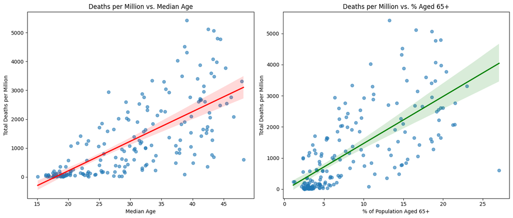

```python
df = pd.read_csv("https://raw.githubusercontent.com/owid/covid-19-data/master/public/data/owid-covid-data.csv", parse_dates=["date"])

cols = ['location', 'median_age', 'aged_65_older', 'total_deaths_per_million']
df_filtered = df[cols].copy()

df_filtered.dropna(subset=cols, inplace=True)
df_filtered = df_filtered[
    (df_filtered['median_age'] > 0) &
    (df_filtered['aged_65_older'] > 0) &
    (df_filtered['total_deaths_per_million'] > 0)
]

df_filtered = df_filtered.groupby('location').agg({
    'median_age': 'first',
    'aged_65_older': 'first',
    'total_deaths_per_million': 'max'
}).reset_index()

death_cap = df_filtered['total_deaths_per_million'].quantile(0.99)
df_filtered = df_filtered[df_filtered['total_deaths_per_million'] <= death_cap]


corr_age, p_age = pearsonr(df_filtered['median_age'], df_filtered['total_deaths_per_million'])
corr_65, p_65 = pearsonr(df_filtered['aged_65_older'], df_filtered['total_deaths_per_million'])

print(f"Correlation between median age and deaths per million: {corr_age:.2f} (p = {p_age:.4f})")
print(f"Correlation between % aged 65+ and deaths per million: {corr_65:.2f} (p = {p_65:.4f})")

plt.figure(figsize=(14, 6))
plt.subplot(1, 2, 1)
sns.regplot(data=df_filtered, x='median_age', y='total_deaths_per_million',
            scatter_kws={'alpha': 0.6}, line_kws={'color': 'red'})
plt.title('Deaths per Million vs. Median Age')
plt.xlabel('Median Age')
plt.ylabel('Total Deaths per Million')

# % Aged 65+ vs. death rate
plt.subplot(1, 2, 2)
sns.regplot(data=df_filtered, x='aged_65_older', y='total_deaths_per_million',
            scatter_kws={'alpha': 0.6}, line_kws={'color': 'green'})
plt.title('Deaths per Million vs. % Aged 65+')
plt.xlabel('% of Population Aged 65+')
plt.ylabel('Total Deaths per Million')

plt.tight_layout()
plt.show()
```

#### **Conclusion**

The analysis supports the hypothesis that countries with a higher overall median age or a larger proportion of individuals aged 65 and older tend to experience higher rates of COVID-19 deaths per million inhabitants. Both the correlation coefficients and regression plots indicate strong positive relationships between these demographic factors and COVID-19 mortality rates. This underscores the importance of considering age demographics in public health strategies and resource allocation during pandemics, as older populations are at significantly greater risk for severe outcomes.

## Hypothesis-7

#### **Countries with greater healthcare resources, particularly more hospital beds per capita, tend to have lower COVID-19 mortality rates.**

The availability of hospital beds is a critical component of healthcare infrastructure. During the COVID-19 pandemic, sufficient hospital bed capacity allowed for timely treatment of patients, reducing the likelihood of severe outcomes and deaths. Conversely, limited bed availability can lead to overwhelmed healthcare systems, delayed care, and increased mortality.

#### **Procedure**

The methodology for analyzing the relationship between healthcare infrastructure and COVID-19 mortality rates involved several key steps:

- **Metric Computation:**

$ Deaths\ per\ Case\ Percentage= \frac{Cumulative\ Deaths\ per\ Million}{Cumulative\ Cases\ per\ Million} \times 100 $

This metric provides insight into the severity and fatality of the disease within each country.

- **Grouping by Healthcare Capacity:** Countries were categorized into three groups—Low, Medium, and High—based on 'hospital_beds_per_thousand' using quantile-based discretization. This stratification allowed for comparative analysis across different levels of healthcare infrastructure.
- **Temporal Analysis:** The average 'deaths_per_case_pct' was computed for each group over time, starting from June 8, 2020. To minimize daily fluctuations and observe broader trends, the data was downsampled to every 10th day.

#### **Results**

```python
df = pd.read_csv("https://raw.githubusercontent.com/owid/covid-19-data/master/public/data/owid-covid-data.csv", parse_dates=["date"])

# Step 1: Data Cleaning & Preprocessing
# --------------------------------------------------
cols = ['location', 'date', 'hospital_beds_per_thousand',
        'new_deaths_per_million', 'new_cases_per_million']
df_filtered = df[cols].copy()
df_filtered.dropna(subset=cols, inplace=True)

df_filtered['date'] = pd.to_datetime(df_filtered['date'])
df_filtered = df_filtered.sort_values(['location', 'date'])
df_filtered = df_filtered[df_filtered['new_cases_per_million'] > 0]

# Step 2: Compute Static and Cumulative Metrics
# --------------------------------------------------
df_filtered['beds'] = df_filtered.groupby('location')['hospital_beds_per_thousand'].transform('first')
df_filtered['cum_deaths_per_million'] = df_filtered.groupby('location')['new_deaths_per_million'].cumsum()
df_filtered['cum_cases_per_million'] = df_filtered.groupby('location')['new_cases_per_million'].cumsum()
df_filtered = df_filtered[df_filtered['cum_cases_per_million'] > 0]
df_filtered['deaths_per_case_pct'] = (df_filtered['cum_deaths_per_million'] / df_filtered['cum_cases_per_million']) * 100

# Step 3: Grouping by Hospital Bed Capacity (3 categories)
# --------------------------------------------------
df_filtered['bed_group'] = pd.qcut(df_filtered['beds'], q=3, labels=["Low", "Medium", "High"])

# Step 4: Prepare Data for Cumulative Animated Plot
# --------------------------------------------------
grouped = df_filtered.groupby(['date', 'bed_group'])['deaths_per_case_pct'].mean().reset_index()

# Downsample and filter from 2020-06-08 onwards
grouped = grouped[(grouped['date'].dt.dayofyear % 10 == 0) & (grouped['date'] >= '2020-06-08')].copy()
grouped['date_str'] = grouped['date'].dt.strftime('%Y-%m-%d')
grouped['bed_group'] = pd.Categorical(grouped['bed_group'], categories=["Low", "Medium", "High"], ordered=True)

# Step 5: Create Animated Bar Chart
# --------------------------------------------------
fig = px.bar(
    grouped,
    x='bed_group',
    y='deaths_per_case_pct',
    color='bed_group',
    animation_frame='date_str',
    animation_group='bed_group',
    range_y=[0, 5],  # max y-axis = 5%
    title="Cumulative COVID-19 Deaths per Reported Case (%) by Hospital Bed Group Over Time",
    labels={
        "bed_group": "Hospital Bed Group",
        "deaths_per_case_pct": "Cumulative Deaths per Case (%)"
    }
)

fig.update_layout(
    showlegend=False,
    xaxis_title="Hospital Bed Group",
    yaxis_title="Cumulative Deaths per Case (%)",
    transition=dict(duration=300, easing='cubic-in-out')
)

fig.show()
```

1. **The temporal analysis** of the average deaths per case percentage across the three groups reveals distinct trends:
   - **Low Bed Capacity Group:** Maintained a higher deaths_per_case_pct, ranging between 4% and 2.5% over time.
   - **Medium Bed Capacity Group:** Observed a moderate deaths_per_case_pct, fluctuating between 3% and 1.5%.
   - **High Bed Capacity Group:** Consistently exhibited the lowest deaths_per_case_pct, decreasing from 2.5% to 0.75%.

#### **Conclusion**

The analysis supports the hypothesis that countries with greater healthcare resources, particularly more hospital beds per capita, tend to have lower COVID-19 mortality rates. The temporal trends indicate that as healthcare capacity increases, the deaths per case percentage decreases, highlighting the critical role of healthcare infrastructure in managing public health crises. This underscores the importance of investing in healthcare resources to improve outcomes during pandemics and other health emergencies.

## Hypothesis-8

#### **Countries that are more developed—those with higher Human Development Index (HDI) and longer life expectancy—are more likely to have higher COVID-19 vaccination percentages compared to developing countries.**

This is because:-

- **Healthcare Infrastructure:** Developed countries generally have better healthcare systems, enabling more efficient vaccine distribution and administration.
- **Public Trust and Awareness:** Higher education and awareness levels in developed countries often correlate with higher vaccine acceptance.
- **Financial Capacity:** Wealthier nations can afford large-scale vaccine procurement and logistics more easily than developing nations.
- **International Priority:** Developed nations were among the first to secure vaccine supplies when global production was limited.

#### **Procedure**

- Calculate Vaccination Percentage: For each record, compute the percentage of people vaccinated by dividing the number of vaccinated individuals by the total population and multiplying by 100.
- Select Most Recent Data: For each country, keep only the most recent available data point to ensure comparability.
- Filter Out Incomplete Records: Remove countries that don’t have data for any of the key metrics: vaccination percentage, HDI, or life expectancy.
- Remove Outliers: Discard entries where the vaccination percentage exceeds 100%, which could result from data inconsistencies.

#### **Results**

```python
# Calculate vaccination percentage
df['vaccination_percentage'] = df['people_vaccinated'] / df['population'] * 100

# Get the latest data for each country
df_latest = df.sort_values('date').groupby('location').last().reset_index()

# Filter out entries with missing values in key columns
cols_needed = ['location', 'vaccination_percentage', 'human_development_index', 'life_expectancy']
df_latest = df_latest.dropna(subset=cols_needed)

## There is value beyod 100 drop them
df_latest = df_latest[df_latest['vaccination_percentage'] <= 100]
df_latest['vaccination_percentage'].describe()


# Plot dynamic scatter plot
fig = px.scatter(
    df_latest,
    x="human_development_index",
    y="life_expectancy",
    size="vaccination_percentage",
    color="vaccination_percentage",
    hover_name="location",
    size_max=15,
    title="Vaccination Percentage in different countries",
    color_continuous_scale=px.colors.sequential.Viridis,
    template='seaborn',
    labels={
        "human_development_index": "Human Development Index (HDI)",
        "vaccination_percentage": "Vaccination Percentage (%)",
        "life_expectancy": "Life Expectancy (Years)"
    }
)

fig.show()
```

#### **Conclusion**

The data strongly supports the hypothesis. The dynamic scatter plot demonstrates a positive correlation between a country’s development indicators (HDI and life expectancy) and its vaccination percentage. Countries like Norway, Switzerland, Japan, and Hong Kong—known for high HDI and long life expectancy—exhibit high vaccination rates. In contrast, countries with lower HDI and life expectancy, such as South Sudan, Niger, and Nigeria, have significantly lower vaccination coverage. This suggests that development status plays a crucial role in a country's capacity to manage mass vaccination during a global health crisis.

## Hypothesis-9

#### **Countries with higher booster vaccination coverage (measured as total_boosters_per_hundred) are expected to have lower hospitalization and ICU admission rates relative to new COVID-19 cases.**

Booster doses help sustain and enhance immunity over time, reducing the severity of COVID-19 infections. This maintained immunity should lead to fewer severe cases that require hospitalization or intensive care, ultimately lowering the rates of hospital and ICU admissions relative to the number of new cases.

#### **Procedure**

The analysis involves first calculating two key ratios: the hospitalization rate, defined as the number of hospitalized patients per million divided by new cases (smoothed per million), and the ICU rate, defined as the number of ICU patients per million divided by new cases (smoothed per million). Next, these ratios are compared across countries against their booster vaccination coverage (total_boosters_per_hundred) using regression plots and correlation analysis.

#### **Results**

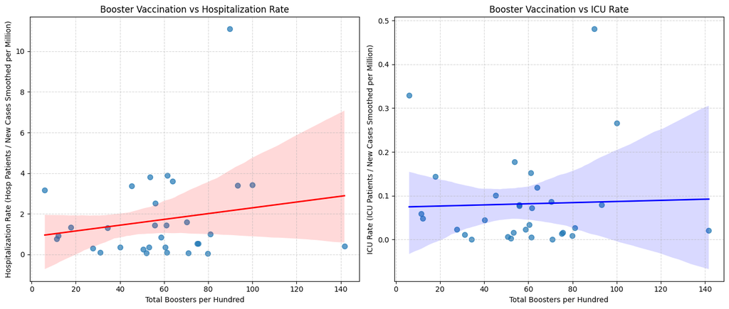

```
Correlation between boosters and hospitalization rate: 0.19
Correlation between boosters and ICU rate: 0.03
```

```python
df = pd.read_csv("https://raw.githubusercontent.com/owid/covid-19-data/master/public/data/owid-covid-data.csv", parse_dates=["date"])

# Define the necessary columns
cols = ['location', 'date', 'total_boosters_per_hundred', 'hosp_patients_per_million',
        'icu_patients_per_million', 'new_cases_smoothed_per_million']

# Filter for the required columns and drop rows with missing values
df_filtered = df[cols].copy()
df_filtered.dropna(subset=cols, inplace=True)

# Ensure new_cases_smoothed_per_million is greater than 0 to avoid division errors
df_filtered = df_filtered[df_filtered['new_cases_smoothed_per_million'] > 0]

# Group by country and take the most recent record per country
df_latest = df_filtered.sort_values('date').groupby('location').last().reset_index()

# Compute the derived metrics:
# Hospitalization Rate = hosp_patients_per_million / new_cases_smoothed_per_million
# ICU Rate = icu_patients_per_million / new_cases_smoothed_per_million
df_latest['hospitalization_rate'] = df_latest['hosp_patients_per_million'] / df_latest['new_cases_smoothed_per_million']
df_latest['icu_rate'] = df_latest['icu_patients_per_million'] / df_latest['new_cases_smoothed_per_million']

# Plotting: Create scatter plots with regression lines to visualize relationships
plt.figure(figsize=(14, 6))

# Scatter plot for Booster Coverage vs Hospitalization Rate
plt.subplot(1, 2, 1)
sns.regplot(
    data=df_latest,
    x='total_boosters_per_hundred',
    y='hospitalization_rate',
    scatter_kws={'s': 50, 'alpha': 0.7},
    line_kws={'color': 'red', 'lw': 2}
)
plt.title('Booster Vaccination vs Hospitalization Rate')
plt.xlabel('Total Boosters per Hundred')
plt.ylabel('Hospitalization Rate (Hosp Patients / New Cases Smoothed per Million)')
plt.grid(True, linestyle='--', alpha=0.5)

# Scatter plot for Booster Coverage vs ICU Rate
plt.subplot(1, 2, 2)
sns.regplot(
    data=df_latest,
    x='total_boosters_per_hundred',
    y='icu_rate',
    scatter_kws={'s': 50, 'alpha': 0.7},
    line_kws={'color': 'blue', 'lw': 2}
)
plt.title('Booster Vaccination vs ICU Rate')
plt.xlabel('Total Boosters per Hundred')
plt.ylabel('ICU Rate (ICU Patients / New Cases Smoothed per Million)')
plt.grid(True, linestyle='--', alpha=0.5)

plt.tight_layout()
plt.show()

# Optionally, print correlation coefficients for additional insight
corr_hosp = df_latest[['total_boosters_per_hundred', 'hospitalization_rate']].corr().iloc[0, 1]
corr_icu = df_latest[['total_boosters_per_hundred', 'icu_rate']].corr().iloc[0, 1]
print(f"Correlation between boosters and hospitalization rate: {corr_hosp:.2f}")
print(f"Correlation between boosters and ICU rate: {corr_icu:.2f}")
```

1. **Regression Plot Analysis:**
   - Both regression plots show a positive relationship between booster vaccination coverage and the derived rates.
   - The correlation between boosters and the hospitalization rate is 0.19, while the correlation between boosters and the ICU rate is 0.03.

These results indicate that, contrary to the initial expectation, the data shows a slight positive association rather than the expected negative association.

#### **Conclusion**

Although the hypothesis predicted that higher booster coverage would correlate with lower hospitalization and ICU rates, the analysis reveals a weak positive relationship. This suggests that other factors might be influencing the severity outcomes, or that the effect of booster coverage on reducing severe cases may be more complex than anticipated. Further investigation and additional variables might be necessary to fully understand the relationship between booster vaccinations and severe COVID-19 outcomes.

## Hypothesis-10

#### **Higher vaccination coverage at the continent level is expected to be associated with lower COVID-19 reproduction rates over time. This means that as more people get vaccinated, the virus should spread less rapidly.**

Vaccines are designed to reduce both the severity of infections and the likelihood of virus transmission. As vaccination coverage increases, more individuals develop immunity, leading to fewer opportunities for the virus to spread. However, occasional increases in reproduction rates may indicate the emergence of new, more transmissible variants that temporarily overcome vaccine-induced immunity.

#### **Results**

```python
import pandas as pd
import plotly.express as px

# Load the dataset and parse dates
df = pd.read_csv("https://raw.githubusercontent.com/owid/covid-19-data/master/public/data/owid-covid-data.csv", parse_dates=["date"])

# Select relevant columns for analysis
cols = ['location', 'date', 'total_vaccinations_per_hundred', 'reproduction_rate', 'continent']
df_vacc = df[cols].copy()

# Drop rows with missing values for vaccination or reproduction rate
df_vacc.dropna(subset=['total_vaccinations_per_hundred', 'reproduction_rate'], inplace=True)

# Optionally, filter out records with non-positive vaccination values
df_vacc = df_vacc[df_vacc['total_vaccinations_per_hundred'] > 0]
df_vacc = df_vacc[df_vacc['reproduction_rate'] > 0]
df_vacc['reproduction_rate'] = df_vacc['reproduction_rate']*100
# Create a string version of the date for animation purposes
df_vacc['date_str'] = df_vacc['date'].dt.strftime('%Y-%m-%d')

# Create an animated scatter plot
fig = px.scatter(
    df_vacc,
    x='total_vaccinations_per_hundred',
    y='reproduction_rate',
    animation_frame='date_str',
    animation_group='continent',
    color='continent',
    size='reproduction_rate',
    hover_name='location',
    size_max=20,
    range_x=[0, df_vacc['total_vaccinations_per_hundred'].max() + 10],
    range_y=[0, df_vacc['reproduction_rate'].max() + 1],
    title='Dynamic Scatter Plot: Vaccination Coverage vs. Reproduction Rate'
)

# Update axis titles for clarity
fig.update_layout(
    xaxis_title='Total Vaccinations per Hundred',
    yaxis_title='Reproduction Rate'
)

fig.show()
```

1. **Scatter Plot Analysis:**
   - The animated scatter plot shows that, as time passes, the sizes of the continent balloons generally decrease, indicating a drop in reproduction rates as vaccination coverage improves. However, there are instances where the balloon size increases, which could suggest the appearance of new COVID-19 variants that temporarily raise the reproduction rate despite high vaccination coverage.

#### **Conclusion**

The analysis supports the notion that increased vaccination coverage correlates with a reduction in COVID-19 transmission at the continent level. While the overall trend shows a decrease in reproduction rates over time, occasional spikes in balloon size highlight the potential impact of emerging variants, emphasizing the need for continued vigilance and possible vaccine updates.

## References

1. OWID COVID-19 Codebook. Available from GitHub: https://github.com/owid/covid-19-data/blob/master/public/data/owid-covid-codebook.csv
2. OWID COVID-19 Data (Old Version). Available from GitHub: https://github.com/owid/covid-19-data/blob/master/public/data/owid-covid-data-old.csv
3. OWID COVID-19 Data. Available from GitHub: https://github.com/owid/covid-19-data/blob/master/public/data/owid-covid-data.csv
4. Impact of COVID-19. Kaggle Notebook by Zabihullah18: https://www.kaggle.com/code/zabihullah18/impact-of-covid-19/notebook
5. EDA on COVID19 India Data. Kaggle Notebook by Saibhargav2810: https://www.kaggle.com/code/saibhargav2810/eda-on-covid19-india-data/notebook